# Examining The Demographics of Shooting Incidents in NYC

Jacob A. Silverstein

Nov 12, 2021

## NYPD Shooting Incidents

Data taken from: *The City of New York* [*(Historic Data)*](https://data.cityofnewyork.us/api/views/833y-fsy8/rows.csv?accessType=DOWNLOAD)

Shooting incidents are all too common in the United States, and no city is immune to violent crime – especially not the Big Apple. In order to better understand the demographics of gun violence in NYC, I have re-organized archived reports of shooting incidents throughout the city by various victim’s data attributes including: `Borough`, `Race`, `Age` and `Sex`. Visualizations of these incidents allow us to explore and analyze some of the trends related to gun violence in NYC.

#### Figure 1

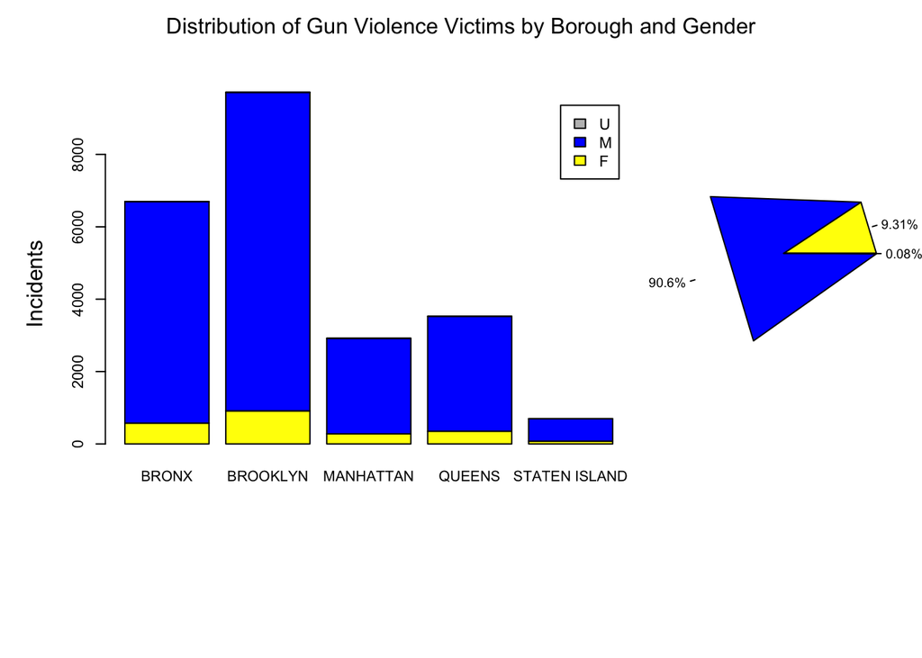

Figure 1 shows us that most of all gun violence incidents in NYC are reported in the Bronx and Brooklyn boroughs. Additionally, nearly all of the victims identify as male, with females making up less than 10% of all victims. According to these reports, Staten Island is the safest borough to be in NYC. Interestingly, the only “unspecified” gender statistic that shows up is located in this borough, which prompts more questions about the Staten Island borough data. Further research could dive into this topic more deeply.

#### Figure 2

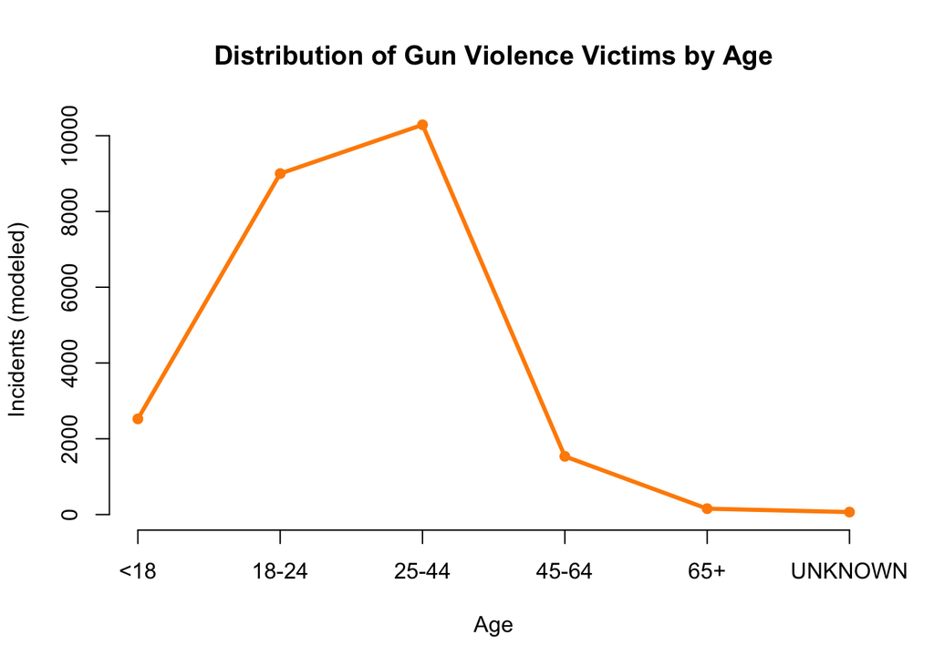

Figure 2 tells us that most gun violence victims in NYC are between the ages of 18 and 44. Interestingly, there are more victims that are less than 18 years old than there are victims that are greater than 45 years old. There are almost no victims older than 65. These data are slightly incomplete in that they do not include the victims’ actual age - rather the categorization of age groups together. Some of these groups have large ranges (for example group 25-44), which leads to further questions such as at what age specifically does gun violence peak for victims. The orange line on the plot represents a model connecting the trends between each age group. This model likely does not reflect the actual trend for where gun violence peaks by age in actuality. These questions could be answered with further research.

#### Figure 3

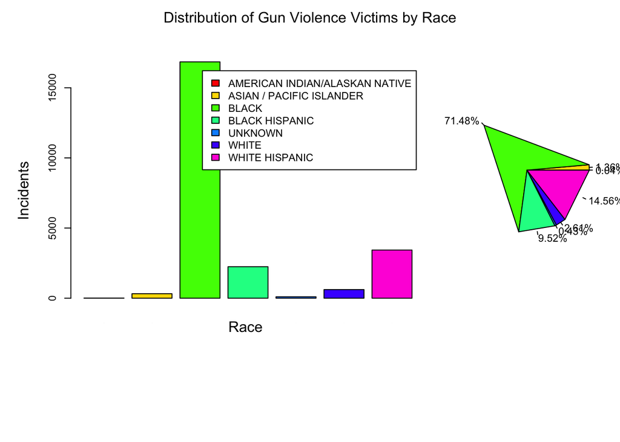

### Conclusion

##### Identifying Bias

My personal bias relating to this project includes my race, gender and the neighborhood where I grew up in. I am a White male who grew up on the northwest side of Chicago, and although I did not grow up in NYC, the gun violence demographics are similar across the nation - especially in Chicago with young Black males on the southwest side making up a largely significant portion of victims. I tried very hard to not bring race into the picture with this project since it is already so largely talked about, but I found that it was actually a very significant aspect of this data set. I had the intention of looking at other aspects of gun violence, but the distribution of incidents by race is perhaps the most important aspect because it so unevenly affects people of color.

#### Table 1

(Showing only the first 10 rows)

```
##          Borough Victim_Age Victim_Sex    Victim_Race
## 1         QUEENS      25-44          M          BLACK
## 2          BRONX      25-44          F          BLACK
## 3      MANHATTAN      18-24          M BLACK HISPANIC
## 4  STATEN ISLAND      25-44          F          BLACK
## 5          BRONX      18-24          M          BLACK
## 6       BROOKLYN      25-44          M          BLACK
## 7       BROOKLYN      25-44          M          BLACK
## 8       BROOKLYN      25-44          M          BLACK
## 9         QUEENS      25-44          M          BLACK
## 10      BROOKLYN      25-44          M          BLACK
```